# Estimating Proportions with Confidence

b06208001 龔泓愷

2018年11月2日

## Q1012

1. `margin of error = 0.98/sqrt(1100) = 0.0295 約= 0.03`

```r
high.c = 0.47 + 0.03;high.c
```

```
## [1] 0.5
```

```r
low.c = 0.47 - 0.03;low.c
```

```
## [1] 0.44
```

**[0.44, 0.5]**

2. The interval computed in part(a) means that we are 95% sure that the actual percentage of American adults who favor the legalization of marijuana is between 44% And 50%.

## Q1022

1. `p-hat = 0.3`
2. `s.e. = sqrt(0.3 * 0.7 / 439) = 0.0219`
3. `[0.3 - 1.96*0.0219, 0.3 + 1.96*0.0219]`  
   **[0.257076, 0.342924]**
4. The interval computed in part(c) means that we are 95% sure that the actual percentage of American teenagers who would rate their parents’ strickness as ‘less strict’ compared to strictness of their friends’ parents is betweeen 0.257076 & 0.342924.

## Q1028

1. `s.e. = sqrt(0.57 * 0.43 / 1006) = 0.0156` `CI = [0.57 - 1.96 * 0.0156, 0.57 + 1.96 * 0.0156]`  
   **[0.539424, 0.600576]**
2. Yes.  
   We are 95% confident that more than half of all Americans supported abortion only under certain circumstances.  
   So, it is reasonable to infer that in 2009 the proportion of those was more than half.
3. `s.e. = sqrt(0.18 * 0.82 / 1006) = 0.0121`  
   `CI = [0.18 - 1.96 * 0.0121, 0.18 + 1.96 * 0.0121]`  
   **[0.156284, 0.203716]**

## Q1054

```r
prop.test(x = c(85, 24), n = c(1105, 1379), alternative = 'two.sided', conf.level = 0.95)
```

```
##
##  2-sample test for equality of proportions with continuity
##  correction
##
## data:  c(85, 24) out of c(1105, 1379)
## X-squared = 50.388, df = 1, p-value = 1.262e-12
## alternative hypothesis: two.sided
## 95 percent confidence interval:
##  0.04154351 0.07749481
## sample estimates:
##     prop 1     prop 2
## 0.07692308 0.01740392
```

**[0.04154, 0.07749]**

2. The interval computed in part(a) means that we are 95% sure that the true proportion of snorers who have a heart disease is between 0.0415 & 0.0775 higher than non-snorers who have a heart disease.  
   On the basis of that, we can infer that the population proportions with heart disease **differ** for snorers and non-snorers.

## 1066

1. Yes.  
   It is reasonable to conclude that the population proportions experiencing sleep apnea differ for men and women since **the intervals do not overlap**.
2. `p1-hat = (0.11 + 0.17)/2 = 0.14`  
   `p2-hat = (0.04 + 0.08)/2 = 0.06`  
   `p1-hat - p2-hat = 0.14 - 0.06 = 0.08`  
   `s.e. = sqrt(0.14 * 0.86 / 524 + 0.06 * 0.94 / 542) = 0.0183`  
   `[0.08 - 1.96 * 0.0183, 0.08 + 1.96 * 0.0183]` = **[0.044132, 0.115868]**
3. The intereval we found in part(b) **does not include 0** which implies the two population proportions are **different**.

## R Function Practice

```r
Prop_CI_Diff <- function(n1, p1, n2, p2, confd){
  #Group1 Simu
  simu.phat1 = c()
  for (i in 1:10000) {
    phat = sum(sample(c(0,1), n1, replace = T, prob = c(1-p1,p1)))/n1
    simu.phat1[i] = phat
  }

  #Group2 Simu
  simu.phat2 = c()
  for (j in 1:10000) {
    phat = sum(sample(c(0,1), n2, replace = T, prob = c(1-p2,p2)))/n2
    simu.phat2[j] = phat
  }

  #Diff Phat
  diff.phat = simu.phat1 - simu.phat2
  diff.phat = sort(diff.phat)

  #
  low.per = ceiling(((1-confd)/2)*10000)
  low.vlue = diff.phat[low.per]
  high.per = ceiling((1-((1-confd)/2))*10000)
  high.vlue = diff.phat[high.per]

  results = c(paste((1-confd)/2*100,"%"), paste((1-((1-confd)/2))*100,"%"), low.vlue, high.vlue)

  mean.p = mean(diff.phat)
  sd.p = sd(diff.phat)

  CI = list(CI = matrix(results, nrow = 2, byrow = T), mean = mean.p, sd = sd.p, simu = diff.phat)

  return(CI)
}
```

### Ex10.10

```r
#Simu
Prop_CI_Diff(1467, 0.624, 1575, 0.490, 0.95)[c('CI','mean', 'sd')]
```

```
## $CI
##      [,1]                 [,2]
## [1,] "2.5 %"              "97.5 %"
## [2,] "0.0987983250559938" "0.169103125912942"
##
## $mean
## [1] 0.1339771
##
## $sd
## [1] 0.01785266
```

```r
#Calcu
n1 = 1467
p1 = 0.624
n2 = 1575
p2 = 0.490

mean = p1 - p2;mean
```

```
## [1] 0.134
```

```r
se = sqrt(p1*(1-p1)/n1 + p2*(1-p2)/n2);se
```

```
## [1] 0.0178494
```

```r
high.c = mean + 1.96 * se;high.c
```

```
## [1] 0.1689848
```

```r
low.c = mean -1.96 * se;low.c
```

```
## [1] 0.09901517
```

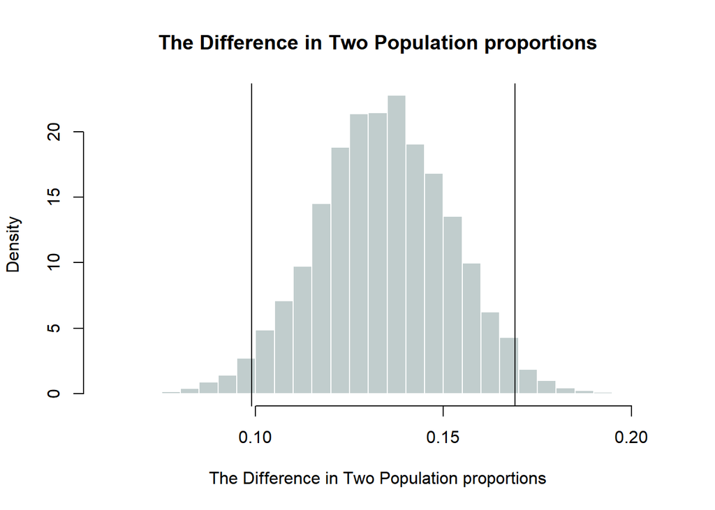

```r
#Hist
Prop_Diff <- as.numeric(as.character(unlist(Prop_CI_Diff(1467, 0.624, 1575, 0.490, 0.95)['simu'])))
hist(Prop_Diff, probability = T, breaks = 20,
   main = 'The Difference in Two Population proportions',
   xlab = 'The Difference in Two Population proportions',
   col = 'azure3', border = 'white')
abline(v = high.c)
abline(v = low.c)
```

可以看出模擬值與理論計算值十分接近。